# MTH6139 Time Series

Coursework 1 - The Canadian Lynx - A project on how we can analyse the changes in the Lynx population in Canada using the time series.

Ceren Gulsun Simsek

Spring term 2025

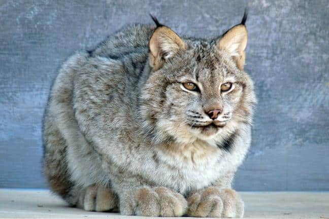

# Introduction: Outlining my Project:

# Section 1: Understanding Lynx and Setting Up our Analysis

## 1.1 ?Help

Using the following code:

```r
?lynx
```

We will then are presented with the description of the data, showing that `lynx` contains the Annual Canadian Lynx trappings between 1821–1934[^2]. As we can clearly see from this time frame there has not been any recent updates to this data. This is where we can later use the time series to help fill in these gaps.

## 1.2 Setting up and working with our initial Data Frame

Let’s start by establishing our initial data frame:

```r
lynx_dates <- as.Date(as.yearmon(time(lynx)))
y_values <- as.numeric(lynx)
lynx_dataframe <- data.frame(ds = lynx_dates, y=y_values)
lynx_time_series <- xts(lynx_dataframe$y, lynx_dataframe$ds)
head(lynx_dataframe)
```

```
##           ds    y
## 1 1821-01-01  269
## 2 1822-01-01  321
## 3 1823-01-01  585
## 4 1824-01-01  871
## 5 1825-01-01 1475
## 6 1826-01-01 2821
```

```r
head(lynx_time_series)
```

```
##            [,1]
## 1821-01-01  269
## 1822-01-01  321
## 1823-01-01  585
## 1824-01-01  871
## 1825-01-01 1475
## 1826-01-01 2821
```

We can see that we’ve produced a data frame which contains date objects and from this we were able to create a time series object which will serve as the basis of our analysis.

Now let’s plot this Time Series!

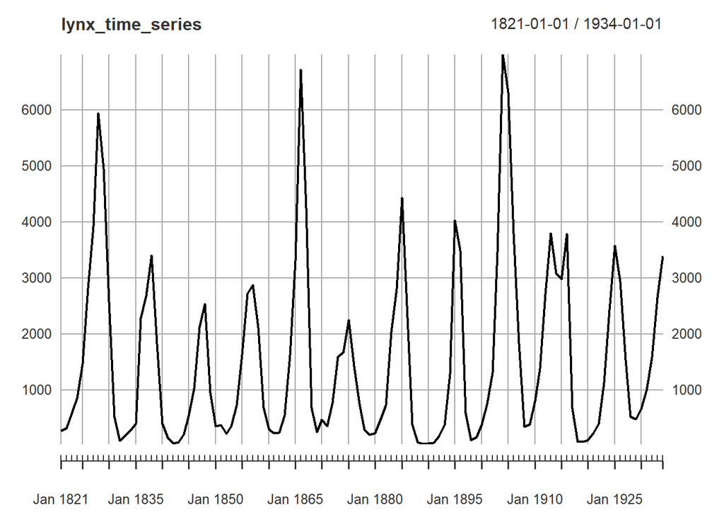

```r
plot(lynx_time_series, type="l")
```

## 1.3 Breusch-Pagan Test

From the plot above, we might notice that the highest “peaks” in the data seem to be increasing, this may suggest a multiplicative model which suggests there may be some heteroskadasticity (variance is not stable). This may mean we need to use a method such as the Box-Cox transformation to then stabilize our variance.

We can attempt to use the Breusch-Pagan Test to see whether the Box-Cox transformation will be appropriate to stabilize the variance. We need to pass a linear model of our data into the test function.

```r
library(lmtest)
model <- lm(y_values ~ lynx_dates)
bptest(model)
```

```
##
##  studentized Breusch-Pagan test
##
## data:  model
## BP = 0.00091294, df = 1, p-value = 0.9759
```

We get a p value of 0.9759 which is > 0.05. This means we do not have enough evidence to reject our null hypothesis that our variance is stable (homoskadasticity). However, the BP test assumes independence which isn’t representative in a population of this nature. By inspection of the previous plot we can clearly visually see the increased change in the “peaks” which in this case means we will still go ahead with our Box-Cox transformation.

## 1.4 Box-Cox Transformation

The Box-Cox transformation gives us a way to deal with the issue of heteroskadasticity. We can see this in the family of functions provided in the lecture notes:

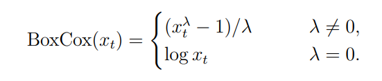

```r
library(forecast)
lambda = BoxCox.lambda(lynx)
lambda
```

```
## [1] 0.1521849
```

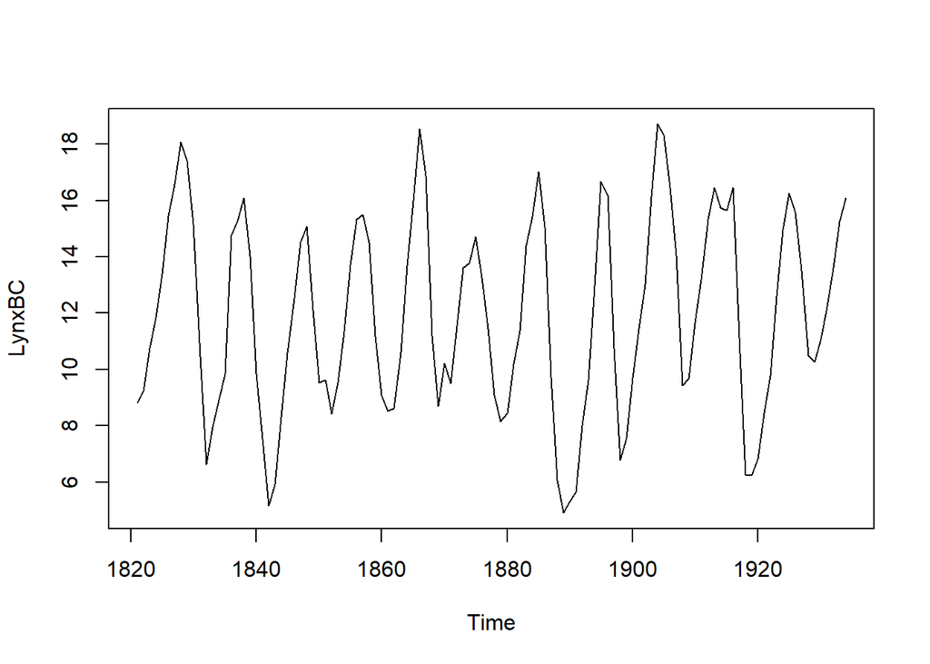

```r
LynxBC = BoxCox(lynx, lambda )
plot(LynxBC)
```

From this we can see the variance has been stabilized, we can also compare this to modelling this against the `log()` function.

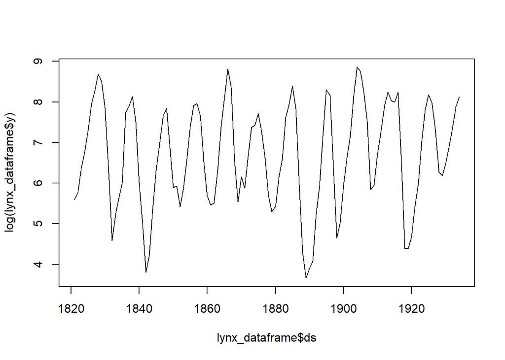

```r
plot(x=lynx_dataframe$ds, y=log(lynx_dataframe$y), type="l")
```

## 1.5 Using Decompose to analyse the Trends and Seasonality of our Time Series

From both examples we can see that the variance of our data has been stabilized, we can now use an additive model in our decompose() function. As the decompose function cannot deal with our default frequency we will set it as 10, the graphs still will capture the population cycles which we will focus on analysing.

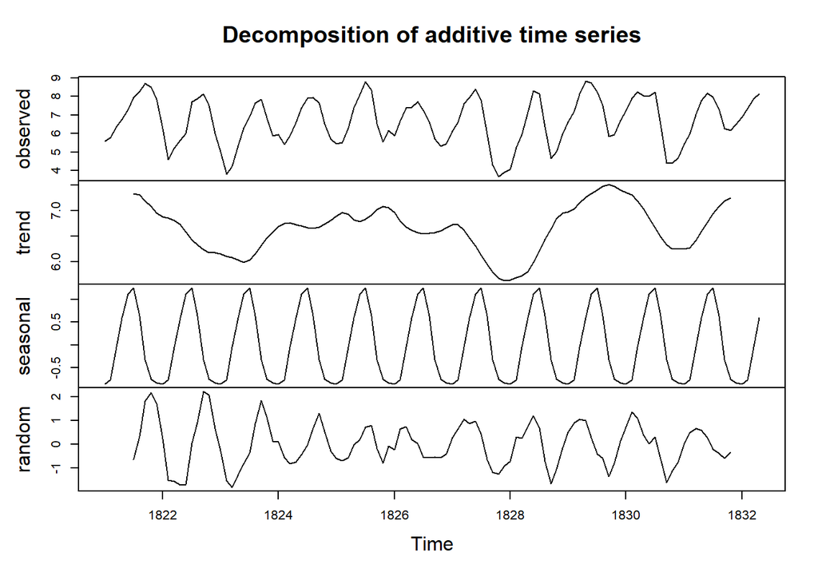

```r
updated_lynx_time_series <- ts(log(lynx_dataframe$y), frequency = 10, start=1821)
decomposition_of_updated_lynx_ts <- decompose(updated_lynx_time_series, type = "additive")
plot(decomposition_of_updated_lynx_ts)
```

```r
decomposition_of_updated_lynx_ts$trend
```

```
## Time Series:
## Start = c(1821, 1)
## End = c(1832, 4)
## Frequency = 10
##   [1]       NA       NA       NA       NA       NA 7.340848 7.314768 7.197610
##   [9] 7.082855 6.961799 6.887127 6.857569 6.810756 6.733049 6.591098 6.436949
##  [17] 6.335919 6.247232 6.183965 6.184914 6.159665 6.108368 6.081975 6.034935
##  [25] 5.996443 6.035950 6.162170 6.325972 6.470958 6.587544 6.690975 6.754425
##  [33] 6.760394 6.734619 6.708405 6.675563 6.656400 6.682030 6.743283 6.818353
##  [41] 6.898680 6.963478 6.926820 6.821167 6.794765 6.838533 6.917525 7.028705
##  [49] 7.083335 7.065648 6.968836 6.804939 6.676966 6.623473 6.575307 6.552541
##  [57] 6.562886 6.572111 6.610352 6.670071 6.732224 6.727291 6.623569 6.471082
##  [65] 6.312000 6.131252 5.959359 5.806648 5.683308 5.639710 5.651512 5.688617
##  [73] 5.727365 5.813883 5.985558 6.216545 6.441155 6.649018 6.844351 6.951202
##  [81] 6.977737 7.038857 7.155352 7.260581 7.343137 7.410190 7.476953 7.518083
##  [89] 7.481891 7.403634 7.366131 7.315973 7.193412 7.042788 6.863996 6.673280
##  [97] 6.487343 6.330950 6.258410 6.255425 6.251646 6.280081 6.415126 6.599059
## [105] 6.779822 6.944180 7.087009 7.198795 7.258150       NA       NA       NA
## [113]       NA       NA
```

```r
decomposition_of_updated_lynx_ts$seasonal
```

```
## Time Series:
## Start = c(1821, 1)
## End = c(1832, 4)
## Frequency = 10
##   [1] -0.85770307 -0.77324015 -0.04588756  0.59846846  1.11483486  1.24735831
##   [7]  0.63659405 -0.33012152 -0.75677727 -0.83352610 -0.85770307 -0.77324015
##  [13] -0.04588756  0.59846846  1.11483486  1.24735831  0.63659405 -0.33012152
##  [19] -0.75677727 -0.83352610 -0.85770307 -0.77324015 -0.04588756  0.59846846
##  [25]  1.11483486  1.24735831  0.63659405 -0.33012152 -0.75677727 -0.83352610
##  [31] -0.85770307 -0.77324015 -0.04588756  0.59846846  1.11483486  1.24735831
##  [37]  0.63659405 -0.33012152 -0.75677727 -0.83352610 -0.85770307 -0.77324015
##  [43] -0.04588756  0.59846846  1.11483486  1.24735831  0.63659405 -0.33012152
##  [49] -0.75677727 -0.83352610 -0.85770307 -0.77324015 -0.04588756  0.59846846
##  [55]  1.11483486  1.24735831  0.63659405 -0.33012152 -0.75677727 -0.83352610
##  [61] -0.85770307 -0.77324015 -0.04588756  0.59846846  1.11483486  1.24735831
##  [67]  0.63659405 -0.33012152 -0.75677727 -0.83352610 -0.85770307 -0.77324015
##  [73] -0.04588756  0.59846846  1.11483486  1.24735831  0.63659405 -0.33012152
##  [79] -0.75677727 -0.83352610 -0.85770307 -0.77324015 -0.04588756  0.59846846
##  [85]  1.11483486  1.24735831  0.63659405 -0.33012152 -0.75677727 -0.83352610
##  [91] -0.85770307 -0.77324015 -0.04588756  0.59846846  1.11483486  1.24735831
##  [97]  0.63659405 -0.33012152 -0.75677727 -0.83352610 -0.85770307 -0.77324015
## [103] -0.04588756  0.59846846  1.11483486  1.24735831  0.63659405 -0.33012152
## [109] -0.75677727 -0.83352610 -0.85770307 -0.77324015 -0.04588756  0.59846846
```

Here we can analyse our trend and seasonal data.

Seasonal: We can see that the pattern in our seasonality remains constant throughout, meaning our variance has been stabilized. Our predator-prey population is also reflected in this, by when the number of predators reaches the local maximum there is more competition over the prey as a food supply, so we then see the gradual decrease before the number of prey is able to sustain the growing population of Lynx. We can see this consistently throughout the seasonality.

## 1.6 Commenting on the Linear Model

For our Lynx data-set (or any population of this nature for that matter) a linear model may not be suitable to model the data as it has cyclical components which cannot alone be captured by a straight line. We could see this earlier in 1.3 where the Breusch-Pagan test didn’t give us a sufficient value of p, despite us visually seeing the need to stabilize the variance.

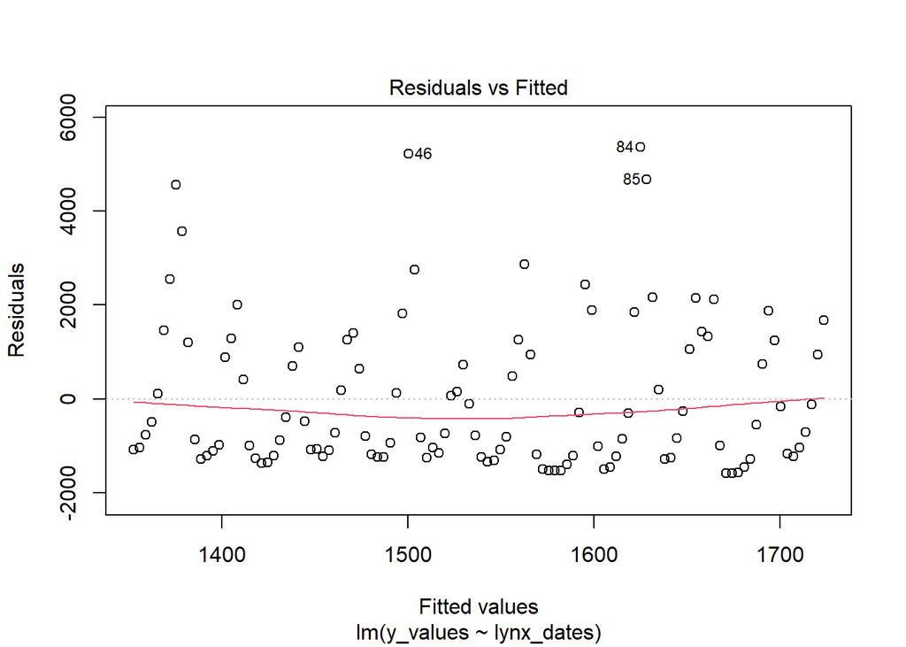

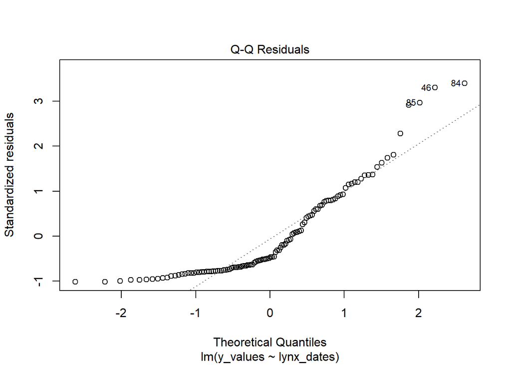

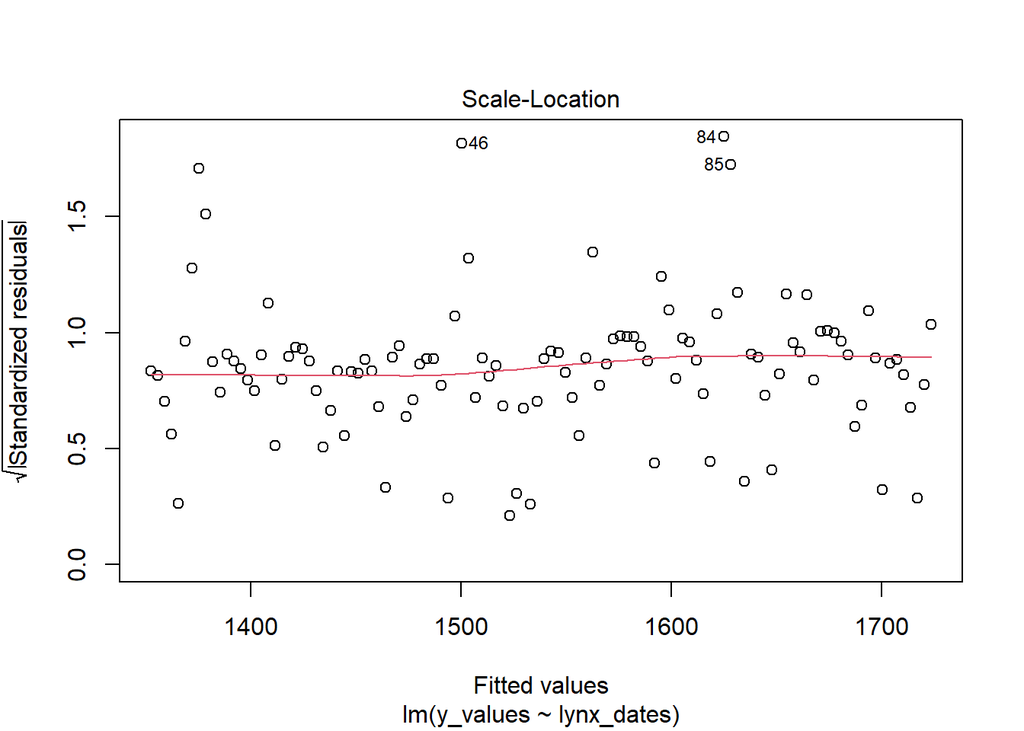

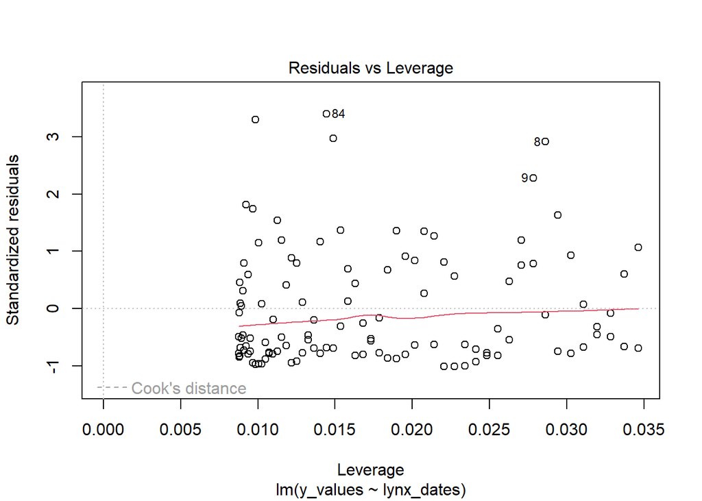

```r
plot(model)
```

We can see some inconsistencies here that might suggest the linear model is not the most appropriate representation of the data.

- In our residuals plot we can see an underlying pattern present in the data, this should be more scattered for a linear model.
- We can also see the clustering of certain values towards the bottom of our data, which may suggest the variance isn’t constant.
- We also have several outliers towards the top of our data which may suggest inconsistent spikes in the data meaning the model might not be suitable to represent this.

This means we can rule out the linear-model as a good representative of our data.

# Section 2: Generating the time series using prophet:

## 2.1 Plotting the forecast

Now we will try to predict the future values of our data using prophet.

```r
library(prophet)
our_forecasting_data <- prophet(lynx_dataframe)
```

```
## Disabling weekly seasonality. Run prophet with weekly.seasonality=TRUE to override this.
```

```
## Disabling daily seasonality. Run prophet with daily.seasonality=TRUE to override this.
```

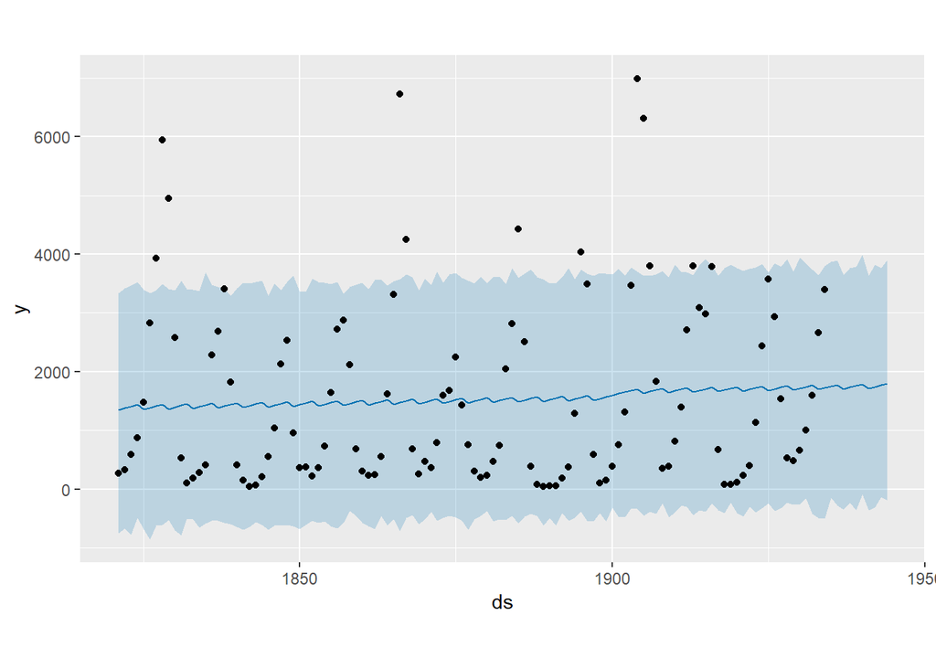

```r
future_df = make_future_dataframe(our_forecasting_data, freq="year", periods = 10)
our_prediction = predict(our_forecasting_data, future_df)
plot(our_forecasting_data, our_prediction)
```

Here we can see our data has been forecasted 10 years into the future. The shaded blue represents the area that the hypothetical future data points would likely fall under.

Let’s see what happens when we now forecast 100 years into the future.

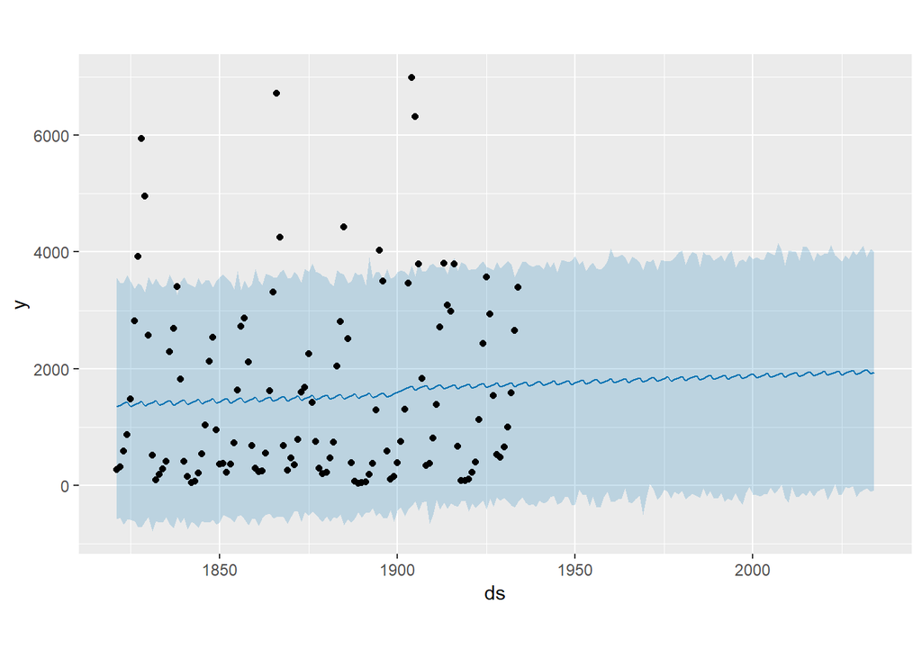

```r
future_df = make_future_dataframe(our_forecasting_data, freq="year", periods = 100)
our_prediction = predict(our_forecasting_data, future_df)
plot(our_forecasting_data, our_prediction)
```

We can how see a steady increase in the light blue region where the majority of our values are predicted to land in.

## 2.2 Analysing the Trend and Seasonality

Using we can now find the trend and seasonality of this information.

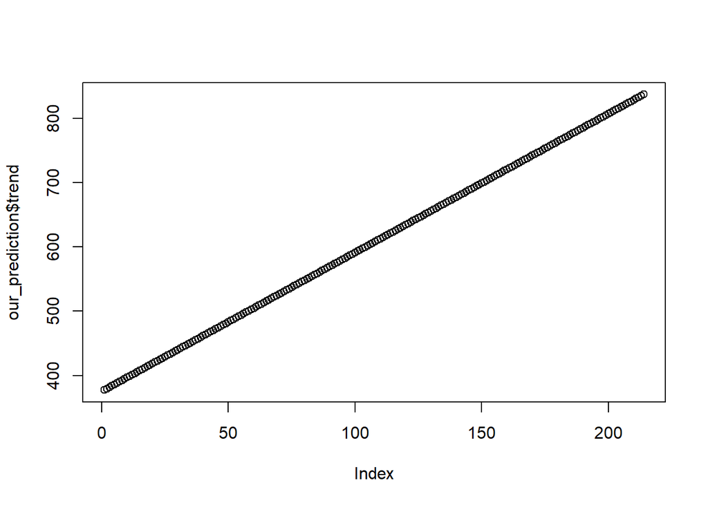

```r
plot(our_prediction$trend)
```

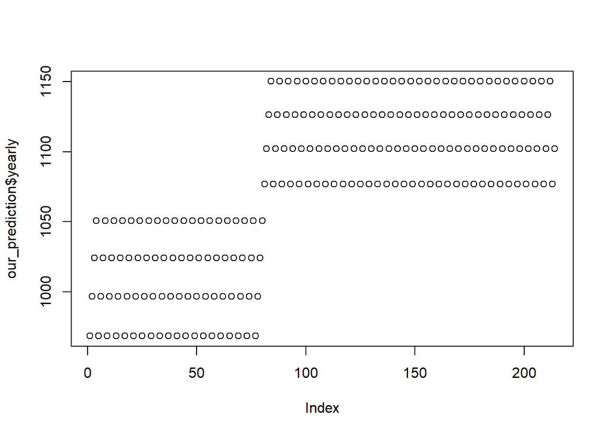

```r
# the yearly seasonality
plot(our_prediction$yearly)
```

We can see for the trend the data looks close to linear, this may mean we have fewer sporadic jumps in our data. We can check this by looking at our change point values in the forecasting data.

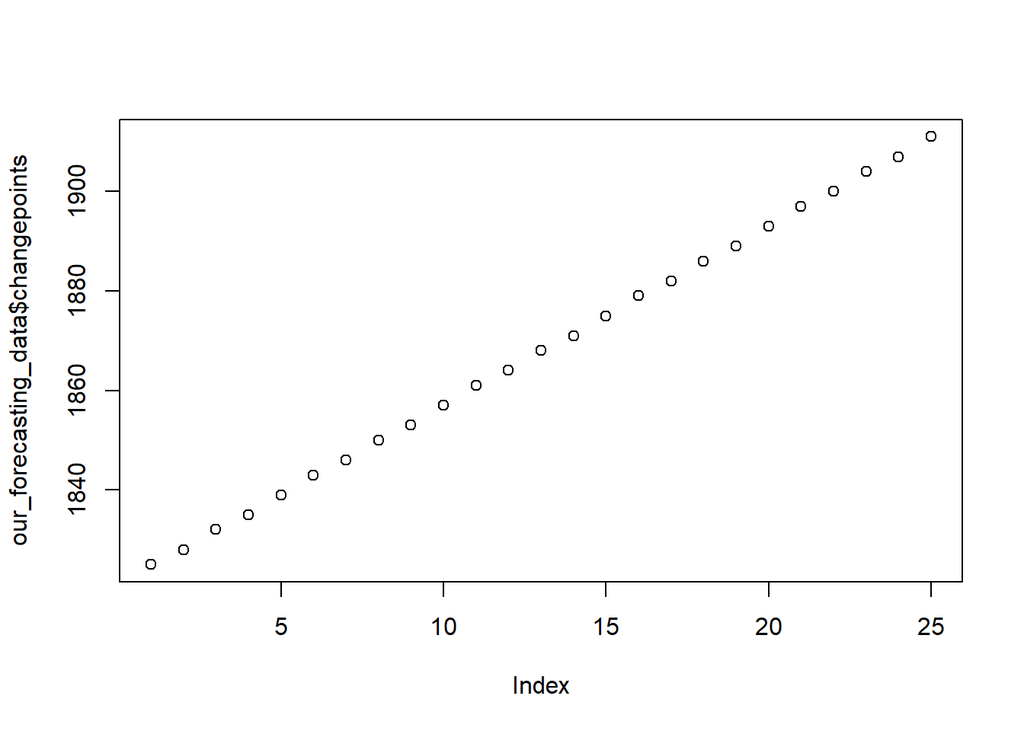

```r
plot(our_forecasting_data$changepoints)
```

We use plotting with prophet to explore this further:

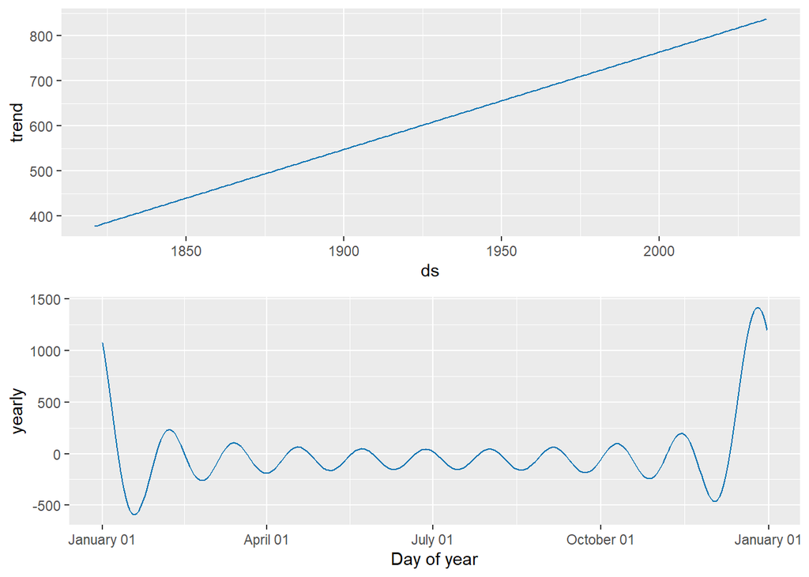

```r
prophet_plot_components(our_forecasting_data, our_prediction)
```

Plotting with prophet gives us a much clearer interpretation of the yearly seasonality. We can see that the highest population of the Canadian Lynx occurs in December and we see a steady increase around winter before a consistent steady fluctuation during spring and summer.

# Section 3: My Conclusion

Overall I felt modelling with an animal population was an interesting way to test the time series and forecasting in prophet. I think if I were to expand this project I would see how the world’s environmental factors may have contributed to this population and found a way of incorporating that into my data.

The seasonality in my data also makes sense given that the Canadian Lynx are adapted to withstand colder climates and less so warmer ones hence their lower sighting during the spring and summer as they may have migrated towards colder areas.

The data itself is also quite dated, and older records may not be the most accurate however the fluctuations and changes in the data are still useful to anayse nonetheless.

I feel this project has made me more confident in exploring data with the Time Series.

# References

[^1]: Maynard Smith, J. (1982). Evolution and the theory of games. Cambridge University Press.
[^2]: https://www.rdocumentation.org/packages/datasets/versions/3.6.2/topics/lynx